# Auditing your model for subgroup deployment readiness

### Discrimination, calibration and clinical utility — and how to run it with `isitfair`

This notebook is the runnable form of `slides/isitfair_audit_tutorial.pdf`. It follows the deck's nine sections in order, and every code block in the deck executes here against real, public data.

### How to read it

The tutorial is built around a worked example — a deployed end-of-surgery infection model. Figures carried over from it are marked **`[study]`**.

Every code cell runs on **SUPPORT2**: 9,105 critically ill adults from the UCI repository, audited on a held-out partition of 1,821. So each idea arrives twice — once as the worked example that motivated it, and once as output you can execute, change and re-run as you read.

### The whole audit on one page

```
  WHAT YOU BRING
  outcome · out-of-fold predicted risk · subgroup labels · threshold t
        │
        ├─── DISCRIMINATION ──── AUROC/AUPRC · TPR/FPR/PPV/NPV · 4 gaps · h
        ├─── CALIBRATION ─────── curve · α · β · Brier/ECE/ICI · H–L
        └─── CLINICAL UTILITY ── decision curve · NB · sNB · zero crossing
        │
  HOW MUCH OF THIS IS NOISE
  patient-level bootstrap · replicate rule · event floors · BH-FDR
        │
  MITIGATION                        WHAT YOU REPORT
  rungs 0/1/2 · isotonic ·          HTML report · TRIPOD+AI ·
  cross-fitting · Wasserstein       prespecification
```

Read down. Each section below marks where it sits on that map.

```python
%matplotlib inline
import sys
import warnings
from pathlib import Path

for _c in (Path.cwd(), *Path.cwd().parents):
    if (_c / "examples" / "support2_data.py").exists():
        sys.path.insert(0, str(_c / "examples"))
        break

import numpy as np
import pandas as pd

import isitfair
from isitfair import (
    DEFAULT_EVENT_FLOORS,
    EVENT_FLOOR_RATIONALE,
    FairnessAudit,
    GroupRecalibration,
    WassersteinPostprocessing,
    compare_periods,
    fdr_correct,
    interaction_test,
)
from support2_data import SEED, THRESHOLD, fit_reference_model

# isitfair forces a head-less backend for report rendering unless an inline one
# is already active, so this must come after the import to take effect.
import matplotlib
matplotlib.use("module://matplotlib_inline.backend_inline")
import matplotlib.pyplot as plt

warnings.filterwarnings("ignore", category=RuntimeWarning)
plt.rcParams.update({"figure.dpi": 110, "savefig.bbox": "tight", "font.size": 9})

B = 200  # keeps every cell responsive; use 2000 for results you report
print(f"isitfair {isitfair.__version__} · backend {matplotlib.get_backend()}")
```

```
isitfair 0.4.0 · backend module://matplotlib_inline.backend_inline
```

# 1 · Why audit at all

### A model that looks finished

`[study]` A deployed end-of-surgery model predicting postoperative bacterial infection. 10,719 procedures, 504 events.

> **AUROC = 0.876** (95% CI 0.859–0.892) Give it one infected and one uninfected patient: it picks the infected one 88% of the time.

By recorded sex: 0.878 in women, 0.875 in men. Paired difference +0.004 (−0.030 to +0.038), p = 0.82.

Every discrimination check passes. Every parity check on sex passes.

**And the model is not ready to deploy.**

### The model says 20%. The real risk is about 8%.

`[study]` Take the model's output at face value and compare it with what actually happened:

| The model shows | 5% | 10% | 20% | 30% |
| --- | --- | --- | --- | --- |
| The real risk is | 1.9% | 3.9% | 8.3% | 13.4% |

A factor of two to three, everywhere on the scale.

> **The previous slide was not wrong. It measured something else.** The model puts patients in very nearly the right *order*. It is the *values* it prints that are wrong. Only the first of those was checked.

### And it is not the same in every patient group

`[study]` Split by physiological reserve and the same 20% on the screen means four different things:

| Stratum | Patients | Infections | Shown 20%, really… |
| --- | --- | --- | --- |
| Overall | 10,719 | 504 | 8.3% |
| Frail | 6,139 | 400 | 9.6% |
| Pre-frail | 3,558 | 98 | 6.1% |
| Non-frail | 1,022 | 6 | 2.1%, *and unsupported* |

Six infections is too few to put an interval around anything, so that last row is a number we show and do not interpret (§7). The frail–pre-frail contrast is estimable, and it is real.

The name for all this is **calibration**. What matters here is the consequence: in one stratum, acting on the score at the intended threshold does *more harm than not using it at all* (§6). No amount of discrimination could have told you that.

### Six words you need before we start

Not fairness vocabulary — just prediction-model evaluation.

- **Rank vs. number.** A score can be right about the *order* of patients and wrong about every *value* it prints. This is the spine of the whole deck.
- **Threshold *t*.** What turns a score into a decision. Anything defined at a threshold describes the decision rule, not the model.
- **Prevalence.** How common the event is in a group. It moves several metrics on its own, model unchanged — so those metrics do not compare across groups.
- **Log-odds.** log(p/(1−p)) stretches [0,1] onto the whole real line, where "every risk is too high" is one number instead of a curve.
- **Bootstrap interval.** Resample your patients, recompute a few thousand times, keep the middle 95%: how far would this move on a different sample?
- **Not estimable.** Too few events to support an interval. The point estimate is still shown; the interval is withheld.

# 2 · The three axes

### Three different questions

|  | Asks | Metrics |
| --- | --- | --- |
| **Discrimination** | Can it tell them apart? | AUROC, AUPRC, TPR, FPR, PPV, NPV |
| **Calibration** | Is the number right? | curve, α, β, Brier, ECE, ICI, H–L |
| **Clinical utility** | Is it worth acting on? | net benefit, sNB, zero crossing |

These are not redundant and **none implies the others**. A model can rank perfectly and print nonsense values; it can be beautifully calibrated and useless at every threshold you would actually deploy at.

> 🔴 **Trap.** Reporting only discrimination. That is what §1 was about.

### Within-group *and* gap — never gaps alone

A gap of zero is not good news by itself: **equal harm is also parity.** Every `isitfair` frame returns the subgroup rows *and* a `GAP` row, and there is no gaps-only mode, deliberately.

### Which axis is primary depends on your use case

- Score used **as a probability** (counselling, resource allocation, thresholded treatment) → calibration and clinical utility are primary.
- Score used **as a ranking** (triage order, worklist) → discrimination and error-rate parity are primary.

> 🔴 **Trap.** A raw subgroup difference is not by itself a model failure. If one group genuinely has higher risk, a model that says so is correct.

### What counts as a subgroup axis

Prespecified; available at prediction time; a mix of sociodemographic *and* clinical; and case-mix reference axes kept separate from the fairness axes.

> 🔴 **Trap.** Auditing only protected attributes. In the deck's study, sex was clean on every axis — and physiological reserve was where the model broke.

# 3 · Setting up your audit

### The four things you must bring

| Input | Notation | Here (SUPPORT2) |
| --- | --- | --- |
| binary outcome | `y_true` | in-hospital mortality |
| predicted risk, **out of fold** | `y_proba` | logistic regression, disjoint training partition |
| subgroup labels | `sensitive_features` | sex, age group, race/ethnicity |
| prespecified operating point | `threshold` | 0.30 |

The package never sees your feature matrix `X`. It evaluates predictions.

Notation used from here: `I_g` the index set of subgroup *g*, `n_g` its size, `n_g⁺` its event count, `π_g⁺` its prevalence, and TP/FP/FN/TN counted at threshold *t*.

### Why the predictions must be out of fold

In-sample predictions are optimistic, and *differentially* so — the optimism is largest in the sparsest subgroups, which is exactly where the audit is trying to look. Any resampling used to fix class imbalance must live **inside the training folds only**.

> 🔴 **Trap** `[study]`. Removing SMOTE moved calibration-in-the-large by **+0.94 logits** — and did not shrink the between-stratum gradient at all. Rebalancing was the level; it was not the disparity.

```python
cohort = fit_reference_model(seed=SEED)
y, p, attrs = cohort.y_test, cohort.p_test, cohort.attrs_test
print(f"audited partition: n = {len(y)}, events = {int(y.sum())}, prevalence = {y.mean():.3f}")
```

```
audited partition: n = 1821, events = 472, prevalence = 0.259
```

### Constructing the audit

The deck's construction, run on SUPPORT2. Note the tuple key: it builds the intersection, and `None` means "derive the cell labels for me".

`FairnessAudit` is **lazy** — nothing is computed until you ask for an axis.

```python
audit = FairnessAudit(
    y_true=y,                            # 0/1, shape (n,)
    y_proba=p,                           # out-of-fold probabilities, shape (n,)
    sensitive_features={
        "sex": attrs["sex"],             # marginal axes: string keys
        "age_group": attrs["age_group"],
        "race_ethnicity": attrs["race_ethnicity"],
        ("sex", "race_ethnicity"): None,  # intersection; None = build labels for me
    },
    threshold=THRESHOLD,                 # prespecified operating threshold
    n_bootstrap=B,
    random_state=SEED,                   # same seed + same data = same numbers
)
print(audit)
```

```
<isitfair.audit.FairnessAudit object at 0x7782389870d0>
```

> 🔴 **Trap.** Passing a tuple key without both of its marginals raises. The intersection is only interpretable next to the axes it is built from.

# 4 · Discrimination

### AUROC — can the model tell them apart?

The Mann–Whitney estimator: the probability that a randomly chosen event outranks a randomly chosen non-event. Threshold-free and prevalence-insensitive.

> 🔴 **Trap.** Comparing subgroup AUROCs as if they were on a common scale. AUROC is a *within-group* ranking quality. A subgroup with a narrow case mix has less to rank and will score lower for reasons that are not about fairness.

### AUPRC — the low-prevalence complement

Trapezoidal area over (TPR, PPV). Its no-skill baseline is the subgroup's own prevalence `π_g⁺`, **not 0.5**.

> 🔴 **Trap.** Ranking subgroups by AUPRC largely ranks their prevalences.

### The rates at your threshold

TPR and FPR are properties of the model's ranking at *t*. PPV and NPV move with prevalence on their own.

> 🔴 **Trap.** Calling a PPV difference "bias". Two groups with different prevalence get different PPV from an identical, perfectly fair model.

```python
disc = audit.discrimination()
disc[disc.subgroup != "GAP"][
    ["attribute", "subgroup", "n", "n_events", "prevalence",
     "auroc", "auroc_ci_low", "auroc_ci_high"]
].round(3)
```

|  | attribute | subgroup | n | n_events | prevalence | auroc | auroc_ci_low | auroc_ci_high |
| --- | --- | --- | --- | --- | --- | --- | --- | --- |
| 0 | sex | Overall | 1821.0 | 472.0 | 0.259 | 0.846 | 0.826 | 0.867 |
| 1 | sex | female | 787.0 | 199.0 | 0.253 | 0.833 | 0.801 | 0.866 |
| 2 | sex | male | 1034.0 | 273.0 | 0.264 | 0.856 | 0.833 | 0.878 |
| 7 | age_group | Overall | 1821.0 | 472.0 | 0.259 | 0.846 | 0.826 | 0.867 |
| 8 | age_group | 18-44 | 257.0 | 65.0 | 0.253 | 0.879 | 0.829 | 0.924 |
| 9 | age_group | 45-64 | 684.0 | 171.0 | 0.250 | 0.860 | 0.829 | 0.892 |
| 10 | age_group | 65-79 | 677.0 | 172.0 | 0.254 | 0.829 | 0.789 | 0.860 |
| 11 | age_group | 80+ | 203.0 | 64.0 | 0.315 | 0.811 | 0.741 | 0.876 |
| 16 | race_ethnicity | Overall | 1821.0 | 472.0 | 0.259 | 0.846 | 0.826 | 0.867 |
| 17 | race_ethnicity | asian | 13.0 | 5.0 | 0.385 | 0.800 | NaN | NaN |
| 18 | race_ethnicity | black | 266.0 | 82.0 | 0.308 | 0.809 | 0.748 | 0.858 |
| 19 | race_ethnicity | hispanic | 57.0 | 10.0 | 0.175 | 0.815 | NaN | NaN |
| 20 | race_ethnicity | other | 32.0 | 9.0 | 0.281 | 0.841 | NaN | NaN |
| 21 | race_ethnicity | white | 1453.0 | 366.0 | 0.252 | 0.855 | 0.829 | 0.876 |
| 26 | sex × race_ethnicity | Overall | 1821.0 | 472.0 | 0.259 | 0.846 | 0.826 | 0.867 |
| 27 | sex × race_ethnicity | female / asian | 2.0 | 2.0 | 0.262 | NaN | NaN | NaN |
| 28 | sex × race_ethnicity | female / black | 127.0 | 40.0 | 0.280 | 0.754 | NaN | NaN |
| 29 | sex × race_ethnicity | female / hispanic | 24.0 | 3.0 | 0.237 | 0.778 | NaN | NaN |
| 30 | sex × race_ethnicity | female / other | 14.0 | 6.0 | 0.267 | 0.938 | NaN | NaN |
| 31 | sex × race_ethnicity | female / white | 620.0 | 148.0 | 0.239 | 0.855 | 0.820 | 0.893 |
| 32 | sex × race_ethnicity | male / asian | 11.0 | 3.0 | 0.265 | 0.792 | NaN | NaN |
| 33 | sex × race_ethnicity | male / black | 139.0 | 42.0 | 0.281 | 0.866 | NaN | NaN |
| 34 | sex × race_ethnicity | male / hispanic | 33.0 | 7.0 | 0.255 | 0.852 | NaN | NaN |
| 35 | sex × race_ethnicity | male / other | 18.0 | 3.0 | 0.254 | 0.756 | NaN | NaN |
| 36 | sex × race_ethnicity | male / white | 833.0 | 218.0 | 0.262 | 0.857 | 0.830 | 0.882 |

What comes back is long-format, with four column groups: **keys** (`attribute`, `subgroup`, `shrunk`), **size** (`n`, `n_events`, `prevalence`), **metrics** (each with `_ci_low`/`_ci_high`), and **reporting** (`n_replicates`, `n_estimable`, `proportion_nonestimable`, `event_floor`, `below_floor`, `not_estimable_final`).

### The four parity gaps

| Gap | Definition | API name |
| --- | --- | --- |
| Δ_EOpp | max−min sensitivity | `equal_opportunity_difference` |
| Δ_PE | max−min false-positive rate | `predictive_equality` |
| Δ_SP | max−min flag rate | `statistical_parity` |
| Δ_EO | max of the first two | `equalized_odds_gap` |

All four are properties of **the decision rule at one *t***. Move *t* and they all move.

**Cohen's *h*** puts a rate gap on an effect-size scale: *h* = 2(arcsin√p₁ − arcsin√p₂), with bands 0.2 / 0.5 / 0.8. Composite and non-rate gaps leave the column blank, since no single rate underlies them.

```python
disc[disc.subgroup == "GAP"][
    ["attribute", "gap_metric", "gap_value", "gap_ci_low", "gap_ci_high"]
].round(4)
```

|  | attribute | gap_metric | gap_value | gap_ci_low | gap_ci_high |
| --- | --- | --- | --- | --- | --- |
| 3 | sex | equal_opportunity_difference | 0.0423 | 0.0026 | 0.1150 |
| 4 | sex | predictive_equality | 0.0311 | 0.0011 | 0.0701 |
| 5 | sex | equalized_odds_gap | 0.0423 | 0.0122 | 0.1150 |
| 6 | sex | statistical_parity | 0.0281 | 0.0012 | 0.0729 |
| 12 | age_group | equal_opportunity_difference | 0.0775 | 0.0474 | 0.2129 |
| 13 | age_group | predictive_equality | 0.1309 | 0.0774 | 0.2138 |
| 14 | age_group | equalized_odds_gap | 0.1309 | 0.0883 | 0.2256 |
| 15 | age_group | statistical_parity | 0.1501 | 0.0813 | 0.2268 |
| 22 | race_ethnicity | equal_opportunity_difference | 0.1049 | NaN | NaN |
| 23 | race_ethnicity | predictive_equality | 0.1630 | NaN | NaN |
| 24 | race_ethnicity | equalized_odds_gap | 0.1630 | NaN | NaN |
| 25 | race_ethnicity | statistical_parity | 0.1346 | NaN | NaN |
| 37 | sex × race_ethnicity | equal_opportunity_difference | 0.2635 | NaN | NaN |
| 38 | sex × race_ethnicity | predictive_equality | 0.0470 | NaN | NaN |
| 39 | sex × race_ethnicity | equalized_odds_gap | 0.2635 | NaN | NaN |
| 40 | sex × race_ethnicity | statistical_parity | 0.1689 | NaN | NaN |

### Reading a gap: three honest verdicts

1. **Descriptive heterogeneity** — real, explained by case mix, not a defect.
2. **Deployment-relevant limitation** — this group is served worse; act.
3. **Not estimable** — too few events to say anything (§7).

### The trap this axis exists to set

`[study]` Discrimination by age group at t = 0.10:

| Age | n | AUROC | Sens | Spec |
| --- | --- | --- | --- | --- |
| 0–17 | 367 | 0.807 | 0.857 | 0.462 |
| 18–44 | 941 | 0.854 | 0.824 | 0.682 |
| 45–64 | 3,715 | 0.888 | 0.918 | 0.666 |
| 65–79 | 4,684 | 0.889 | 0.912 | 0.654 |
| ≥80 | 1,012 | 0.805 | 0.849 | 0.577 |

Sex Δ_EO was 0.010. Age Δ_EO was **0.220** — driven almost entirely by specificity. The axis that looked fine and the axis that did not were both in the same audit; only one of them is a protected attribute.

# 5 · Calibration

**What it means:** E[Y | p, A=g] = p. Among the patients this model told you were at 20% risk, in subgroup *g*, about 20% should have the event.

Assessed three ways, none sufficient alone.

### 1 — The calibration curve

LOESS with 95% bootstrap bands, clipped to each stratum's own predicted range. The only output that shows you *where* on the risk scale it fails.

### 2 — Calibration-in-the-large: the intercept α

Fit `logit Pr(Y=1) = α_g + l_i` with the slope **pinned at 1**, where `l_i` is the predicted log-odds.

*In words:* one number for "every risk in this group is too high / too low".

> 🔴 **Trap.** α is prevalence-dependent. Report the window it was computed in, always. An α quoted without its population is not interpretable.

### 3 — The slope β

Fit with **both** terms free. β < 1: predictions too spread out (the classic overfitting signature). β > 1: too compressed — which is what class rebalancing tends to leave behind.

> 🔴 **Trap.** The free fit's intercept is a *different quantity* from α. Never quote it as calibration-in-the-large.

```python
cal = audit.calibration()
cal[cal.subgroup != "GAP"][
    ["attribute", "subgroup", "n", "n_events",
     "calibration_intercept", "intercept_ci_low", "intercept_ci_high",
     "calibration_slope", "slope_ci_low", "slope_ci_high"]
].round(3)
```

|  | attribute | subgroup | n | n_events | calibration_intercept | intercept_ci_low | intercept_ci_high | calibration_slope | slope_ci_low | slope_ci_high |
| --- | --- | --- | --- | --- | --- | --- | --- | --- | --- | --- |
| 0 | sex | Overall | 1821.0 | 472.0 | 0.082 | -0.044 | 0.208 | 1.034 | 0.934 | 1.135 |
| 1 | sex | female | 787.0 | 199.0 | -0.030 | -0.211 | 0.131 | 1.008 | 0.879 | 1.182 |
| 2 | sex | male | 1034.0 | 273.0 | 0.171 | 0.012 | 0.348 | 1.063 | 0.942 | 1.201 |
| 5 | age_group | Overall | 1821.0 | 472.0 | 0.082 | -0.044 | 0.208 | 1.034 | 0.934 | 1.135 |
| 6 | age_group | 18-44 | 257.0 | 65.0 | -0.025 | -0.389 | 0.217 | 1.174 | NaN | NaN |
| 7 | age_group | 45-64 | 684.0 | 171.0 | 0.267 | 0.038 | 0.459 | 1.113 | 0.966 | 1.356 |
| 8 | age_group | 65-79 | 677.0 | 172.0 | -0.049 | -0.262 | 0.138 | 0.963 | 0.810 | 1.115 |
| 9 | age_group | 80+ | 203.0 | 64.0 | 0.078 | -0.276 | 0.348 | 0.978 | NaN | NaN |
| 12 | race_ethnicity | Overall | 1821.0 | 472.0 | 0.082 | -0.044 | 0.208 | 1.034 | 0.934 | 1.135 |
| 13 | race_ethnicity | asian | 13.0 | 5.0 | 0.675 | NaN | NaN | 0.949 | NaN | NaN |
| 14 | race_ethnicity | black | 266.0 | 82.0 | 0.336 | -0.073 | 0.684 | 0.871 | NaN | NaN |
| 15 | race_ethnicity | hispanic | 57.0 | 10.0 | -0.493 | NaN | NaN | 0.948 | NaN | NaN |
| 16 | race_ethnicity | other | 32.0 | 9.0 | 0.431 | NaN | NaN | 0.941 | NaN | NaN |
| 17 | race_ethnicity | white | 1453.0 | 366.0 | 0.039 | -0.111 | 0.184 | 1.078 | 0.957 | 1.204 |
| 20 | sex × race_ethnicity | Overall | 1821.0 | 472.0 | 0.082 | -0.044 | 0.208 | 1.034 | 0.934 | 1.135 |
| 21 | sex × race_ethnicity | female / asian | 2.0 | 2.0 | NaN | NaN | NaN | NaN | NaN | NaN |
| 22 | sex × race_ethnicity | female / black | 127.0 | 40.0 | 0.274 | NaN | NaN | 0.650 | NaN | NaN |
| 23 | sex × race_ethnicity | female / hispanic | 24.0 | 3.0 | -0.960 | NaN | NaN | 0.759 | NaN | NaN |
| 24 | sex × race_ethnicity | female / other | 14.0 | 6.0 | 1.416 | NaN | NaN | 1.351 | NaN | NaN |
| 25 | sex × race_ethnicity | female / white | 620.0 | 148.0 | -0.112 | -0.300 | 0.076 | 1.140 | 0.982 | 1.407 |
| 26 | sex × race_ethnicity | male / asian | 11.0 | 3.0 | 0.148 | NaN | NaN | 0.863 | NaN | NaN |
| 27 | sex × race_ethnicity | male / black | 139.0 | 42.0 | 0.392 | NaN | NaN | 1.214 | NaN | NaN |
| 28 | sex × race_ethnicity | male / hispanic | 33.0 | 7.0 | -0.197 | NaN | NaN | 1.121 | NaN | NaN |
| 29 | sex × race_ethnicity | male / other | 18.0 | 3.0 | -0.513 | NaN | NaN | 0.860 | NaN | NaN |
| 30 | sex × race_ethnicity | male / white | 833.0 | 218.0 | 0.156 | -0.030 | 0.360 | 1.049 | 0.905 | 1.206 |

### 4 — Brier, ECE, ICI: three aggregate scores

- **Brier** — mean squared error of the probabilities. A *proper* score, but prevalence-dependent.
- **ECE** — expected calibration error, binned; K = 10 equal-frequency bins.
- **ICI** — the binless version: mean |observed − predicted| against the LOESS curve.

When ECE and ICI disagree, the binning is doing the work — trust ICI.

> 🔴 **Trap.** Comparing Brier across strata of different prevalence. It will rank them by prevalence.

```python
cal[cal.subgroup != "GAP"][["attribute", "subgroup", "n", "brier", "ece", "ici"]].round(4)
```

|  | attribute | subgroup | n | brier | ece | ici |
| --- | --- | --- | --- | --- | --- | --- |
| 0 | sex | Overall | 1821.0 | 0.1293 | 0.0191 | 0.0137 |
| 1 | sex | female | 787.0 | 0.1309 | 0.0228 | 0.0095 |
| 2 | sex | male | 1034.0 | 0.1281 | 0.0344 | 0.0265 |
| 5 | age_group | Overall | 1821.0 | 0.1293 | 0.0191 | 0.0137 |
| 6 | age_group | 18-44 | 257.0 | 0.1124 | 0.0333 | 0.0192 |
| 7 | age_group | 45-64 | 684.0 | 0.1212 | 0.0380 | 0.0311 |
| 8 | age_group | 65-79 | 677.0 | 0.1366 | 0.0357 | 0.0258 |
| 9 | age_group | 80+ | 203.0 | 0.1537 | 0.0387 | 0.0246 |
| 12 | race_ethnicity | Overall | 1821.0 | 0.1293 | 0.0191 | 0.0137 |
| 13 | race_ethnicity | asian | 13.0 | 0.2006 | 0.3488 | 0.1884 |
| 14 | race_ethnicity | black | 266.0 | 0.1573 | 0.0552 | 0.0432 |
| 15 | race_ethnicity | hispanic | 57.0 | 0.1060 | 0.0981 | 0.0571 |
| 16 | race_ethnicity | other | 32.0 | 0.1257 | 0.1236 | 0.0694 |
| 17 | race_ethnicity | white | 1453.0 | 0.1245 | 0.0238 | 0.0141 |
| 20 | sex × race_ethnicity | Overall | 1821.0 | 0.1293 | 0.0191 | 0.0137 |
| 21 | sex × race_ethnicity | female / asian | 2.0 | 0.3617 | 0.5714 | NaN |
| 22 | sex × race_ethnicity | female / black | 127.0 | 0.1749 | 0.0975 | 0.0661 |
| 23 | sex × race_ethnicity | female / hispanic | 24.0 | 0.1185 | 0.1908 | 0.1435 |
| 24 | sex × race_ethnicity | female / other | 14.0 | 0.1653 | 0.2467 | 0.1855 |
| 25 | sex × race_ethnicity | female / white | 620.0 | 0.1208 | 0.0244 | 0.0183 |
| 26 | sex × race_ethnicity | male / asian | 11.0 | 0.1713 | 0.3083 | 0.1940 |
| 27 | sex × race_ethnicity | male / black | 139.0 | 0.1411 | 0.0995 | 0.0701 |
| 28 | sex × race_ethnicity | male / hispanic | 33.0 | 0.0969 | 0.1664 | 0.0842 |
| 29 | sex × race_ethnicity | male / other | 18.0 | 0.0949 | 0.1969 | 0.1132 |
| 30 | sex × race_ethnicity | male / white | 833.0 | 0.1273 | 0.0327 | 0.0252 |

### 5 — Hosmer–Lemeshow: what the test actually asks

Sort by predicted risk, cut into 10 groups, compare observed against expected. It asks a single yes/no question about the *whole* curve at once.

> 🔴 **Trap.** A large p-value is **not evidence of calibration**. It is a failure to detect miscalibration — which in a small subgroup is the expected outcome whether the model is calibrated or not.

### …and the degrees-of-freedom question

Use **df = g, not g − 2**. The g − 2 correction exists because the model estimated its coefficients on the same data. Out-of-fold predictions estimated nothing here, so subtracting 2 is unearned — and roughly doubles the false miscalibration rate.

```python
hl = audit.hosmer_lemeshow()  # df_mode defaults to "validation", i.e. df = g
hl[hl.subgroup != "GAP"][
    ["attribute", "subgroup", "n", "hl_statistic", "hl_df", "hl_p_value",
     "n_bins_used", "bins_reduced", "decile_slope", "decile_intercept"]
].round(3)
```

|  | attribute | subgroup | n | hl_statistic | hl_df | hl_p_value | n_bins_used | bins_reduced | decile_slope | decile_intercept |
| --- | --- | --- | --- | --- | --- | --- | --- | --- | --- | --- |
| 0 | sex | Overall | 1821.0 | 6.984 | 10.0 | 0.727 | 10.0 | False | 1.035 | 0.002 |
| 1 | sex | female | 787.0 | 4.889 | 10.0 | 0.898 | 10.0 | False | 1.000 | -0.004 |
| 2 | sex | male | 1034.0 | 11.610 | 10.0 | 0.312 | 10.0 | False | 1.074 | 0.004 |
| 4 | age_group | Overall | 1821.0 | 6.984 | 10.0 | 0.727 | 10.0 | False | 1.035 | 0.002 |
| 5 | age_group | 18-44 | 257.0 | 3.456 | 10.0 | 0.969 | 10.0 | False | 1.060 | -0.018 |
| 6 | age_group | 45-64 | 684.0 | 9.862 | 10.0 | 0.453 | 10.0 | False | 1.114 | 0.008 |
| 7 | age_group | 65-79 | 677.0 | 9.414 | 10.0 | 0.493 | 10.0 | False | 0.928 | 0.012 |
| 8 | age_group | 80+ | 203.0 | 2.581 | 10.0 | 0.990 | 10.0 | False | 1.031 | 0.003 |
| 10 | race_ethnicity | Overall | 1821.0 | 6.984 | 10.0 | 0.727 | 10.0 | False | 1.035 | 0.002 |
| 11 | race_ethnicity | asian | 13.0 | 12.591 | 10.0 | 0.247 | 10.0 | False | 0.650 | 0.277 |
| 12 | race_ethnicity | black | 266.0 | 11.804 | 10.0 | 0.298 | 10.0 | False | 0.953 | 0.058 |
| 13 | race_ethnicity | hispanic | 57.0 | 7.163 | 10.0 | 0.710 | 10.0 | False | 0.848 | -0.020 |
| 14 | race_ethnicity | other | 32.0 | 10.851 | 10.0 | 0.369 | 10.0 | False | 1.061 | 0.040 |
| 15 | race_ethnicity | white | 1453.0 | 7.201 | 10.0 | 0.706 | 10.0 | False | 1.046 | -0.006 |
| 17 | sex × race_ethnicity | Overall | 1821.0 | 6.984 | 10.0 | 0.727 | 10.0 | False | 1.035 | 0.002 |
| 18 | sex × race_ethnicity | female / asian | 2.0 | NaN | NaN | NaN | 2.0 | True | NaN | NaN |
| 19 | sex × race_ethnicity | female / black | 127.0 | 16.818 | 10.0 | 0.078 | 10.0 | False | 0.777 | 0.100 |
| 20 | sex × race_ethnicity | female / hispanic | 24.0 | 7.474 | 10.0 | 0.680 | 10.0 | False | 0.430 | 0.039 |
| 21 | sex × race_ethnicity | female / other | 14.0 | 9.742 | 10.0 | 0.463 | 10.0 | False | 1.175 | 0.167 |
| 22 | sex × race_ethnicity | female / white | 620.0 | 5.179 | 10.0 | 0.879 | 10.0 | False | 1.070 | -0.033 |
| 23 | sex × race_ethnicity | male / asian | 11.0 | 8.818 | 10.0 | 0.549 | 10.0 | False | 0.717 | 0.104 |
| 24 | sex × race_ethnicity | male / black | 139.0 | 16.489 | 10.0 | 0.086 | 10.0 | False | 1.160 | 0.014 |
| 25 | sex × race_ethnicity | male / hispanic | 33.0 | 15.408 | 10.0 | 0.118 | 10.0 | False | 1.073 | -0.049 |
| 26 | sex × race_ethnicity | male / other | 18.0 | 11.470 | 10.0 | 0.322 | 10.0 | False | 1.097 | -0.051 |
| 27 | sex × race_ethnicity | male / white | 833.0 | 12.206 | 10.0 | 0.272 | 10.0 | False | 1.059 | 0.005 |

```python
deciles = audit.hosmer_lemeshow(detail=True)   # observed vs expected per risk group
curves = audit.calibration_curves()            # LOESS + bootstrap band
print(f"decile tables: {len(deciles)} rows · calibration curves: {len(curves)} rows")
```

```
decile tables: 242 rows · calibration curves: 2500 rows
```

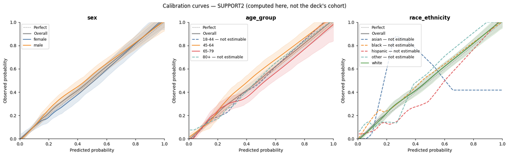

```python
from isitfair import reliability_plot

fig, axes = plt.subplots(1, 3, figsize=(15, 4.6))
for ax, axis in zip(axes, ("sex", "age_group", "race_ethnicity")):
    reliability_plot(curves, attribute=axis, calibration=cal, ax=ax, title=axis)
fig.suptitle("Calibration curves — SUPPORT2 (computed here, not the deck's cohort)")
fig.tight_layout()
plt.show()
```

### Calibration gaps

`max_intercept_gap` and `max_slope_gap`. Note they are filed under their **own** metric names, not under the subgroup metric — a gap is a different quantity with a different floor.

`[study]` The largest reserve gap was **1.62 logits** — and it rested on the six-event stratum, so it got no interval. The estimable frail–pre-frail contrast was **0.49 (0.28 to 0.71)**. That is the number the paper reports.

```python
cal[cal.subgroup == "GAP"][["attribute", "gap_metric", "gap_value", "gap_ci_low", "gap_ci_high"]].round(3)
```

|  | attribute | gap_metric | gap_value | gap_ci_low | gap_ci_high |
| --- | --- | --- | --- | --- | --- |
| 3 | sex | max_intercept_gap | 0.201 | 0.018 | 0.471 |
| 4 | sex | max_slope_gap | 0.055 | 0.005 | 0.288 |
| 10 | age_group | max_intercept_gap | 0.316 | 0.188 | 0.757 |
| 11 | age_group | max_slope_gap | 0.211 | NaN | NaN |
| 18 | race_ethnicity | max_intercept_gap | 1.167 | NaN | NaN |
| 19 | race_ethnicity | max_slope_gap | 0.207 | NaN | NaN |
| 31 | sex × race_ethnicity | max_intercept_gap | 2.376 | NaN | NaN |
| 32 | sex × race_ethnicity | max_slope_gap | 0.701 | NaN | NaN |

# 6 · Clinical utility

### The question a decision curve answers

Not "is the model accurate" but "**is acting on it better than the two strategies that need no model at all**" — treat everyone, or treat no one.

> 🔴 **Trap.** The treat-all reference must use **each subgroup's own prevalence**. A pooled prevalence flatters low-prevalence subgroups, because it credits them against a baseline that is not theirs.

### Net benefit

NB_g(t) = TP/n − (FP/n)·t/(1−t)

*In words:* count the true positives you gain, then subtract the false positives you cause, priced at the exchange rate the threshold implies. Multiply by 1,000 to read it as "net true positives per 1,000 patients".

### Where t/(1−t) comes from — and what it is not

At t = 0.10 the odds are 1:9 — you are willing to accept nine false positives per true positive. This is **arithmetic from the threshold**, not an independently elicited preference. Sweep a band (the deck uses 0.05–0.20); draw the full 0.02–0.40.

### Standardized net benefit

sNB = NB / π_g⁺ — net benefit as a fraction of the maximum achievable in that group, which makes groups with different prevalence comparable.

### The utility gap, and the zero crossing

ΔNB_max is taken over the threshold grid and all subgroup pairs. The **zero crossing** is the *t* at which acting on the model stops being worth it; it has a closed form, t* = TP/(TP+FP).

```python
dca = audit.decision_curve(
    thresholds=[0.20, 0.25, 0.30, 0.35, 0.40],
    zero_crossing=True,
)
dca[dca.subgroup != "GAP"][
    ["attribute", "subgroup", "threshold", "net_benefit",
     "standardized_net_benefit", "treat_all_nb", "zero_crossing"]
].round(4).head(15)
```

|  | attribute | subgroup | threshold | net_benefit | standardized_net_benefit | treat_all_nb | zero_crossing |
| --- | --- | --- | --- | --- | --- | --- | --- |
| 0 | sex | Overall | 0.20 | 0.1558 | 0.6012 | 0.0740 | NaN |
| 1 | sex | Overall | 0.25 | 0.1378 | 0.5318 | 0.0123 | NaN |
| 2 | sex | Overall | 0.30 | 0.1269 | 0.4894 | -0.0583 | NaN |
| 3 | sex | Overall | 0.35 | 0.1078 | 0.4157 | -0.1397 | NaN |
| 4 | sex | Overall | 0.40 | 0.0950 | 0.3665 | -0.2347 | NaN |
| 5 | sex | female | 0.20 | 0.1401 | 0.5540 | 0.0661 | NaN |
| 6 | sex | female | 0.25 | 0.1271 | 0.5025 | 0.0038 | NaN |
| 7 | sex | female | 0.30 | 0.1225 | 0.4846 | -0.0673 | NaN |
| 8 | sex | female | 0.35 | 0.0996 | 0.3939 | -0.1494 | NaN |
| 9 | sex | female | 0.40 | 0.0894 | 0.3534 | -0.2452 | NaN |
| 10 | sex | male | 0.20 | 0.1678 | 0.6355 | 0.0800 | NaN |
| 11 | sex | male | 0.25 | 0.1460 | 0.5531 | 0.0187 | NaN |
| 12 | sex | male | 0.30 | 0.1301 | 0.4929 | -0.0514 | NaN |
| 13 | sex | male | 0.35 | 0.1140 | 0.4317 | -0.1323 | NaN |
| 14 | sex | male | 0.40 | 0.0993 | 0.3761 | -0.2266 | NaN |

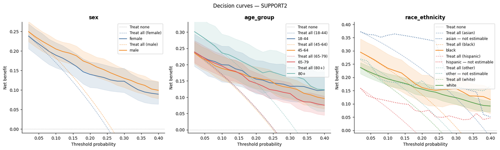

```python
from isitfair import decision_curve_plot

curve = audit.decision_curve()   # default grid: 0.02 -> 0.40, 20 points
fig, axes = plt.subplots(1, 3, figsize=(15, 4.5))
for ax, axis in zip(axes, ("sex", "age_group", "race_ethnicity")):
    decision_curve_plot(curve, attribute=axis, ax=ax, title=axis)
fig.suptitle("Decision curves — SUPPORT2")
fig.tight_layout()
plt.show()
```

# 7 · Uncertainty, floors and multiplicity

### What the bootstrap resamples — and why it matters

B = 2,000 percentile intervals. Two schemes exist:

- **`"patient"`** (the default) resamples patients within each subgroup stratum, preserving *n* while letting the event count vary.
- **`"case_control"`** resamples cases and non-cases separately, which **fixes** the event count and estimates uncertainty *conditional on the observed prevalence*.

The second suits rank-based metrics, where prevalence is not part of what you are estimating. `patient` is the default because most of the axes here — calibration intercept and slope, Brier, PPV/NPV, net benefit — do depend on prevalence. Both remain available.

### Why the choice of scheme matters

`[study]` On the six-event stratum, for the calibration intercept:

| Scheme | 95% CI | Width |
| --- | --- | --- |
| `case_control` | (−2.55, −2.40) | 0.15 |
| `patient` | — | **1.76** |

A tenfold difference in width. And because `case_control` cannot produce a zero-event replicate, its non-estimability diagnostics read 0% by construction — which is why `patient` is the default: it is the scheme that lets the diagnostics see sparse strata at all.

### Three properties your bootstrap should have

1. **One overall resample per replicate**, reused across every axis.
2. **Gaps are reductions of the stored replicates**, not a second independent draw.
3. **Seeded from (entropy, stream, attribute_id, b)** — so results are order-independent and bit-identical at a fixed `random_state`.

### Rule 1 — the replicate rule

NaN replicates are **not dropped** — dropping them conditions the interval on success and narrows it. If more than 10% of replicates are non-estimable, the cell is "not estimable".

The interval is conditional on estimability from the **first** failed replicate, not from the 10% mark.

### Rule 2 — the event floors

Motivated by SE ≈ 0.5/√E:

```python
for metric, floor in sorted(DEFAULT_EVENT_FLOORS.items()):
    print(f"  {metric:>24} : {floor:>4} events")
print()
print(EVENT_FLOOR_RATIONALE)
```

[output not shown]

### The conservative union — and what suppression means

> **not reportable = below the floor OR more than 10% non-estimable**

A gap inherits the failure of **either** constituent stratum.

And suppression withholds the **interval, never the point estimate**. A suppressed point is still a real quantity — it simply has no defensible uncertainty around it. In figures those points are drawn dashed, with a hollow marker.

```python
audit_floors = FairnessAudit(
    y_true=y, y_proba=p, sensitive_features=attrs,
    threshold=THRESHOLD, n_bootstrap=B, random_state=SEED,
    resample_scheme="patient",       # rule 0: the right scheme
    nonestimable_threshold=0.10,     # rule 1
    event_floors={                   # rule 2
        "auroc": 25, "calibration_intercept": 25,
        "calibration_slope": 100, "net_benefit": 50,
    },
)
est = audit_floors.estimability()
est[est.not_estimable_final][
    ["attribute", "subgroup", "metric", "n", "n_events",
     "event_floor", "below_floor", "proportion_nonestimable", "rule"]
].head(20)
```

|  | attribute | subgroup | metric | n | n_events | event_floor | below_floor | proportion_nonestimable | rule |
| --- | --- | --- | --- | --- | --- | --- | --- | --- | --- |
| 4 | age_group | 18-44 | calibration_slope | 257.0 | 65.0 | 100.0 | True | 0.0 | below its pre-registered event floor |
| 37 | age_group | 80+ | calibration_slope | 203.0 | 64.0 | 100.0 | True | 0.0 | below its pre-registered event floor |
| 47 | age_group | GAP | max_slope_gap | NaN | NaN | 100.0 | True | 0.0 | inherits the calibration_slope event floor fro... |
| 61 | race_ethnicity | GAP | equal_opportunity_difference | NaN | NaN | 25.0 | True | 0.0 | inherits the auroc event floor from its consti... |
| 62 | race_ethnicity | GAP | equalized_odds_gap | NaN | NaN | 25.0 | True | 0.0 | inherits the auroc event floor from its consti... |
| 63 | race_ethnicity | GAP | max_intercept_gap | NaN | NaN | 25.0 | True | 0.0 | inherits the calibration_intercept event floor... |
| 64 | race_ethnicity | GAP | max_slope_gap | NaN | NaN | 100.0 | True | 0.0 | inherits the calibration_slope event floor fro... |
| 65 | race_ethnicity | GAP | predictive_equality | NaN | NaN | 25.0 | True | 0.0 | inherits the auroc event floor from its consti... |
| 66 | race_ethnicity | GAP | statistical_parity | NaN | NaN | 25.0 | True | 0.0 | inherits the auroc event floor from its consti... |
| 78 | race_ethnicity | asian | auprc | 13.0 | 5.0 | 25.0 | True | 0.0 | below its pre-registered event floor |
| 79 | race_ethnicity | asian | auroc | 13.0 | 5.0 | 25.0 | True | 0.0 | below its pre-registered event floor |
| 80 | race_ethnicity | asian | brier | 13.0 | 5.0 | 25.0 | True | 0.0 | below its pre-registered event floor |
| 81 | race_ethnicity | asian | calibration_intercept | 13.0 | 5.0 | 25.0 | True | 0.0 | below its pre-registered event floor |
| 82 | race_ethnicity | asian | calibration_slope | 13.0 | 5.0 | 100.0 | True | 0.0 | below its pre-registered event floor |
| 83 | race_ethnicity | asian | net_benefit | 13.0 | 5.0 | 50.0 | True | NaN | below its pre-registered event floor |
| 84 | race_ethnicity | asian | npv | 13.0 | 5.0 | 25.0 | True | 0.0 | below its pre-registered event floor |
| 85 | race_ethnicity | asian | ppv | 13.0 | 5.0 | 25.0 | True | 0.0 | below its pre-registered event floor |
| 87 | race_ethnicity | asian | sensitivity | 13.0 | 5.0 | 25.0 | True | 0.0 | below its pre-registered event floor |
| 88 | race_ethnicity | asian | specificity | 13.0 | 5.0 | 25.0 | True | 0.0 | below its pre-registered event floor |
| 93 | race_ethnicity | black | calibration_slope | 266.0 | 82.0 | 100.0 | True | 0.0 | below its pre-registered event floor |

### Multiplicity: correct within families, not globally

Benjamini–Hochberg at q = 0.05, applied **within prespecified families**. Correcting across every number in a paper at once mixes unrelated questions into one error rate; a family is the set of tests that share a question. Within-subgroup point estimates are left uncorrected — they are descriptions, not tests.

```python
# A three-test family: does mortality risk differ by sex within each condition?
frame = cohort.frame_test.copy()
frame["cancer"] = (frame["ca"] != "no").astype(int)
frame["age_years"], frame["severity"] = frame["age"], frame["aps"]

pvals, rows = [], []
for cond in ("diabetes", "dementia", "cancer"):
    res = interaction_test(
        frame, outcome="y", sensitive="sex", covariate=cond,
        adjust_for=("age_years", "severity"),   # NUMERIC columns
    )
    rows.append({"covariate": cond, "p_value": res.p_value, "delta_r2": res.delta_r2})
    pvals.append(res.p_value)

family = pd.DataFrame(rows)
family["q_fdr"] = fdr_correct(pvals)
family.round(4)
```

|  | covariate | p_value | delta_r2 | q_fdr |
| --- | --- | --- | --- | --- |
| 0 | diabetes | 0.2785 | 0.0006 | 0.8262 |
| 1 | dementia | 0.9472 | 0.0000 | 0.9472 |
| 2 | cancer | 0.5508 | 0.0002 | 0.8262 |

### Interaction tests: is the *effect* different, or just the rate?

Nested logistic models M0 (main effects) and M1 (with the interaction), compared by likelihood ratio ~ χ².

> 🔴 **Trap.** Always report `p_value` **and** `delta_r2` (Nagelkerke). With n in the thousands, a vanishing interaction is still detectable — and a detectable interaction that explains 0.08% of the variance is not a finding you should act on.

# 8 · Mitigation

### Climb the ladder — do not jump to the top

| Rung | What | Uses group membership? |
| --- | --- | --- |
| 0 · none | the model as it stands | — |
| 1 · common | one cohort-wide recalibration | **no** |
| 2 · group-specific | a separate map per subgroup | yes |

`[study]` Rung 1 alone took α from **−1.020 to −0.007** and cut the frail–pre-frail gap to 0.308 — without using group membership at all. Rung 2 reduced the residual to 0.005, at a cost the next cell shows.

### Isotonic recalibration

A monotone least-squares step function. It **preserves rank**, so AUROC is untouched by construction — and because it is fitted per group, it needs enough events per group to be worth using.

### Cross-fitting: the transform is a fitted model too

> 🔴 **Trap.** Cross-fit on the model's **own** fold ids. A recalibration map fitted and evaluated on the same rows carries exactly the in-sample optimism the audit exists to remove.

```python
ladder = audit.recalibration_ladder(
    method="isotonic",
    by="race_ethnicity",
    cv=5,                  # or folds=published_fold_ids to reuse the model's own
    random_state=SEED,
)
ladder[["rung", "subgroup", "n", "n_events", "calibration_intercept",
        "calibration_slope", "ece", "not_estimable_final"]].round(3)
```

|  | rung | subgroup | n | n_events | calibration_intercept | calibration_slope | ece | not_estimable_final |
| --- | --- | --- | --- | --- | --- | --- | --- | --- |
| 0 | none | Overall | 1821.0 | 472.0 | 0.082 | 1.034 | 0.019 | False |
| 1 | none | asian | 13.0 | 5.0 | 0.675 | 0.949 | 0.349 | True |
| 2 | none | black | 266.0 | 82.0 | 0.336 | 0.871 | 0.055 | True |
| 3 | none | hispanic | 57.0 | 10.0 | -0.493 | 0.948 | 0.098 | True |
| 4 | none | other | 32.0 | 9.0 | 0.431 | 0.941 | 0.124 | True |
| 5 | none | white | 1453.0 | 366.0 | 0.039 | 1.078 | 0.024 | False |
| 6 | none | GAP | NaN | NaN | NaN | NaN | NaN | NaN |
| 7 | common | Overall | 1821.0 | 472.0 | 0.000 | 0.767 | 0.016 | False |
| 8 | common | asian | 13.0 | 5.0 | 0.707 | 0.725 | 0.365 | True |
| 9 | common | black | 266.0 | 82.0 | 0.244 | 0.511 | 0.078 | True |
| 10 | common | hispanic | 57.0 | 10.0 | -0.556 | 0.918 | 0.120 | True |
| 11 | common | other | 32.0 | 9.0 | 0.396 | 0.801 | 0.124 | True |
| 12 | common | white | 1453.0 | 366.0 | -0.043 | 0.824 | 0.018 | False |
| 13 | common | GAP | NaN | NaN | NaN | NaN | NaN | NaN |
| 14 | group_specific | Overall | 1821.0 | 472.0 | 0.009 | 0.432 | 0.021 | False |
| 15 | group_specific | asian | 13.0 | 5.0 | 0.349 | 0.075 | 0.318 | True |
| 16 | group_specific | black | 266.0 | 82.0 | -0.002 | 0.205 | 0.047 | True |
| 17 | group_specific | hispanic | 57.0 | 10.0 | 0.064 | 0.114 | 0.092 | True |
| 18 | group_specific | other | 32.0 | 9.0 | 0.283 | 0.061 | 0.131 | True |
| 19 | group_specific | white | 1453.0 | 366.0 | 0.004 | 0.686 | 0.020 | False |
| 20 | group_specific | GAP | NaN | NaN | NaN | NaN | NaN | NaN |

### When the ladder tells you to stop

`[study]` The non-frail stratum had 6 events. Isotonic produced a degenerate map and the post-recalibration slope came back at **0.12**, against 0.93 overall. The published conclusion was: adopt **common** recalibration, defer group-specific until the endpoint is measured comparably.

**The same thing happens on SUPPORT2**, on entirely different data — look at what group-specific recalibration does to the calibration slope in the small race/ethnicity strata below. A rung you cannot support is worse than the rung beneath it.

```python
audit_pre = FairnessAudit(
    y_true=y, y_proba=p, sensitive_features=attrs,
    threshold=THRESHOLD, n_bootstrap=B, random_state=SEED,
)
mitigated = audit_pre.mitigate(
    method=GroupRecalibration(method="isotonic"),
    calibration_data=(cohort.y_calib, cohort.p_calib, cohort.attrs_calib),
)
cols = ["subgroup", "n", "n_events", "calibration_intercept", "calibration_slope"]
before = audit_pre.calibration()
after = mitigated["race_ethnicity"].calibration()
(
    before[before.attribute == "race_ethnicity"][cols]
    .merge(after[after.attribute == "race_ethnicity"][cols],
           on=["subgroup", "n", "n_events"], suffixes=("_before", "_after"))
    .round(3)
)
```

|  | subgroup | n | n_events | calibration_intercept_before | calibration_slope_before | calibration_intercept_after | calibration_slope_after |
| --- | --- | --- | --- | --- | --- | --- | --- |
| 0 | Overall | 1821.0 | 472.0 | 0.082 | 1.034 | 0.058 | 0.629 |
| 1 | asian | 13.0 | 5.0 | 0.675 | 0.949 | 0.998 | 0.647 |
| 2 | black | 266.0 | 82.0 | 0.336 | 0.871 | 0.247 | 0.443 |
| 3 | hispanic | 57.0 | 10.0 | -0.493 | 0.948 | -0.980 | 0.114 |
| 4 | other | 32.0 | 9.0 | 0.431 | 0.941 | -0.732 | 0.079 |
| 5 | white | 1453.0 | 366.0 | 0.039 | 1.078 | 0.052 | 0.906 |
| 6 | GAP | NaN | NaN | NaN | NaN | NaN | NaN |
| 7 | GAP | NaN | NaN | NaN | NaN | NaN | NaN |
| 8 | GAP | NaN | NaN | NaN | NaN | NaN | NaN |
| 9 | GAP | NaN | NaN | NaN | NaN | NaN | NaN |

### Score-distribution parity, and why it is a comparator

The Wasserstein barycenter of the per-subgroup score distributions. It gives **exact** demographic parity and preserves within-subgroup AUROC.

> 🔴 **Trap.** Expect calibration to move. Calibration and equalized odds cannot both hold when prevalence differs across groups (Pleiss et al. 2017), so this belongs in a comparison rather than as a default choice.

```python
w = audit_pre.mitigate(
    method=WassersteinPostprocessing(constraint="demographic_parity"),
    calibration_data=(cohort.y_calib, cohort.p_calib, cohort.attrs_calib),
)
w_cal = w["race_ethnicity"].calibration()
w_cal[w_cal.attribute == "race_ethnicity"][cols + ["brier", "ece"]].round(3)
```

|  | subgroup | n | n_events | calibration_intercept | calibration_slope | brier | ece |
| --- | --- | --- | --- | --- | --- | --- | --- |
| 12 | Overall | 1821.0 | 472.0 | 0.073 | 1.029 | 0.130 | 0.019 |
| 13 | asian | 13.0 | 5.0 | 1.416 | 1.580 | 0.265 | 0.383 |
| 14 | black | 266.0 | 82.0 | 0.323 | 0.894 | 0.157 | 0.061 |
| 15 | hispanic | 57.0 | 10.0 | -0.533 | 0.895 | 0.108 | 0.086 |
| 16 | other | 32.0 | 9.0 | 1.039 | 1.308 | 0.145 | 0.170 |
| 17 | white | 1453.0 | 366.0 | 0.009 | 1.078 | 0.124 | 0.023 |
| 18 | GAP | NaN | NaN | NaN | NaN | NaN | NaN |
| 19 | GAP | NaN | NaN | NaN | NaN | NaN | NaN |

# 9 · Reporting, and the whole thing at once

### Sparse intersectional cells

```python
audit.cell_diagnostics().round(3)
```

|  | attribute | subgroup | n | n_events | shrunk | marginal_rate | cell_rate | shrinkage_factor |
| --- | --- | --- | --- | --- | --- | --- | --- | --- |
| 0 | sex × race_ethnicity | female / asian | 2 | 2 | True | 0.253 | 1.000 | 0.988 |
| 1 | sex × race_ethnicity | female / black | 127 | 40 | True | 0.253 | 0.315 | 0.565 |
| 2 | sex × race_ethnicity | female / hispanic | 24 | 3 | True | 0.253 | 0.125 | 0.873 |
| 3 | sex × race_ethnicity | female / other | 14 | 6 | True | 0.253 | 0.429 | 0.922 |
| 4 | sex × race_ethnicity | female / white | 620 | 148 | False | 0.253 | 0.239 | 0.210 |
| 5 | sex × race_ethnicity | male / asian | 11 | 3 | True | 0.264 | 0.273 | 0.938 |
| 6 | sex × race_ethnicity | male / black | 139 | 42 | True | 0.264 | 0.302 | 0.543 |
| 7 | sex × race_ethnicity | male / hispanic | 33 | 7 | True | 0.264 | 0.212 | 0.834 |
| 8 | sex × race_ethnicity | male / other | 18 | 3 | True | 0.264 | 0.167 | 0.902 |
| 9 | sex × race_ethnicity | male / white | 833 | 218 | False | 0.264 | 0.262 | 0.165 |

### The report

Self-contained HTML, no JavaScript, with 300-DPI PNGs written to a sibling `audit_report_figures/` directory.

It contains ten sections: the audit summary, Table 1 with effect sizes and BH-FDR, the three axes with forest and ROC plots, the H–L per-group observed vs expected tables, the intersectional cell diagnostics, the before/after mitigation comparison, a TRIPOD+AI appendix, and a "how to read this report" section.

```python
# Written to a scratch directory here; point `out=` wherever you want it.
import tempfile

_scratch = Path(tempfile.mkdtemp(prefix="isitfair-tutorial-"))

report_path = audit.report(
    out=_scratch / "tutorial_audit_report.html",
    title="Tutorial — SUPPORT2 subgroup deployment-readiness audit",
    metadata={
        "Model": "Logistic regression (SUPPORT2 ICU mortality)",
        "Cohort": f"n={len(y)} held-out test partition",
        "Threshold": str(THRESHOLD),
        "Predictions": "out-of-fold, disjoint training partition",
    },
    mitigation_audits=mitigated,        # optional before/after section
    # table_one_data=cohort_df,         # optional cohort characterisation
)
print(f"wrote {report_path.name} to a scratch directory")
print(f"  {Path(report_path).stat().st_size / 1e6:.1f} MB, self-contained")
print(f"  figures: {len(list(_scratch.glob('*_figures/*.png')))} PNGs alongside it")
```

```
wrote tutorial_audit_report.html to a scratch directory
  2.1 MB, self-contained
  figures: 19 PNGs alongside it
```

### The whole audit, end to end

Everything above, as the script you would actually write:

```
import numpy as np, pandas as pd
from isitfair import FairnessAudit

audit = FairnessAudit(
    y_true=y, y_proba=p_oof,
    sensitive_features={"sex": sex, "age_group": age, "reserve": reserve,
                        ("sex", "reserve"): None},
    threshold=0.10, n_bootstrap=2000, random_state=42,
    resample_scheme="patient", nonestimable_threshold=0.10,
    event_floors={"auroc": 25, "calibration_intercept": 25,
                  "calibration_slope": 100, "net_benefit": 50},
)

results = audit.run_all()      # discrimination, calibration, hosmer_lemeshow,
                               # decision_curve, in one call
est = audit.estimability()     # what you are allowed to put an interval on

for name, frame in results.items():
    frame.to_csv(f"{name}.csv", index=False)
est.to_csv("estimability_enforced.csv", index=False)

audit.report(out="audit_report.html", title="...", metadata={...})
```

### Optional: comparing two periods

```
from isitfair import compare_periods

dev  = FairnessAudit(y_dev,  p_dev,  attrs_dev,  threshold=0.10, **cfg)
hold = FairnessAudit(y_hold, p_hold, attrs_hold, threshold=0.10, **cfg)

by_period = compare_periods({"2018-2020": dev, "2021-2022": hold})
```

You build each audit and hand them over, which keeps the modelling decisions — which rows, which model, which threshold — in your hands.

```python
results = audit.run_all()
print("run_all() returned:", list(results))
```

```
run_all() returned: ['discrimination', 'roc_curves', 'calibration', 'calibration_curves', 'hosmer_lemeshow', 'decision_curve', 'estimability']
```

### Prespecify these, before you look at anything

1. The subgroup axes, and which are case-mix reference axes.
2. Which axis is **primary** for your use case.
3. The threshold, and the band you will sweep around it.
4. The event floors.
5. The FDR families.
6. That predictions are out-of-fold, and that any recalibration is cross-fitted.

### What a finished audit establishes

Five statements you can make about your model, each backed by a table:

1. **Which subgroups it was measured in**, and how well the data supports each estimate — the estimability verdict travels with every number.
2. **Which axis carries the finding**: discrimination, calibration or clinical utility. They are independent, so this is real information.
3. **How to read each gap** — a deployment-relevant difference, case-mix heterogeneity the model is right to reflect, or a contrast the cohort is too sparse to resolve.
4. **Which remedy the evidence supports**, and how far up the ladder that evidence reaches.
5. **What was prespecified**, and what came from looking.

### Getting it

```
pip install isitfair          # Python >= 3.10
```

Start with `examples/support2_mortality_audit.py` — a real model on the public UCI SUPPORT2 cohort, including the train/calibration/test split that leak-free mitigation requires.

https://github.com/HugoGuillen/isitfair